# Important Course Information

STA200 - Statistics II

May 26 - June 28, 2026

# 1 Introduction

**This is a 100% online, asynchronous course.**

The materials will be delivered in a distance learning format (online) through the course website (https://pengdsci.github.io/STA200/). You are expected to check this page frequently during this 5-week summer semester for updates and new course materials.

**D2L is used only for weekly exams and the final exam. All weekly topic lists and lecture notes are available exclusively on the course website, not on D2L**

The course materials are structured in a modular format, with each module focusing on a specific topic or theme. At the end of each week, you will take a weekly exam through D2L covering all topics from that week’s three modules.

# 2 What Are You Expected to Do Every Week?

You will complete three modules each week, which are structured in the right navigation panel on the course webpage (https://pengdsci.github.io/STA200/). For each module,

- **Study the module notes**:

For each module note, you are expected to

- Study the content to understand the concepts and procedures.
- Watch the embedded short videos (if available) in the note to reinforce your understanding.
- work through the examples (i.e., not simply read the worked out examples ) and check the provided answers.
- Practice all R commands (code) provided in the module note.
- **After completing all modules**, go to **D2L** to take the **weekly exam**, which covers topics from all modules. There are **four weekly exams** and a **final exam**.
- After finishing all three modules, go to D2L to complete the weekly exam that covers all topics from the modules covered in the week. There are four weekly exams and a final exam. Each exam has a standalone web page with detailed information about the exam.
- **To find the weekly exam on D2L**,
  - Log in to D2L using your WCU login credentials.
  - Click the course icon (shown below) to access the course page.

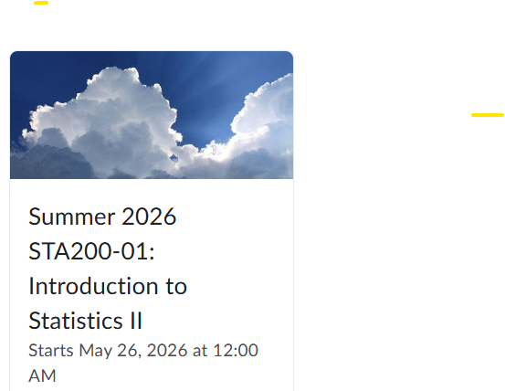

+ From the **Assessments** drop-down menu, select **Quizzes**. + Click the link for the appropriate weekly quiz.

# 3 Some Advice

This is a short and intensive summer course. To enhance your online learning experience and achieve your goals, I offer the following advice:

- Start early on weekly materials - **never wait until the last minute**. Procrastination will ruin your progress.
- Practice (**Don’t Just Read**) Examples. Treat multiple-choice problems as “show-your-work” problems. Solve them step by step, then select the correct answer based on your reasoning.
- **Seeking Help When Needed**: If you struggle with certain concepts or examples, write them down and reach out to me as early as possible. Remember: You can succeed regardless of your prior math experience. Challenges are part of learning - don’t hesitate to ask for help from me or your peers. Never give up!

# 4 Some Additional Information on Exams

**No Make-up Weekly Exams** – You have **two and a half days** to complete the exams. I will post the solutions on the corresponding exam-specific web pages.

- **Additional Information About Weekly Midterm Exams**:
  - Each **weekly exam** contains about **30 multiple-choice questions**. There are **no show-your-work** problems.
  - Every student will receive a different version of the weekly exam, **all with the same level of difficulty**.
  - You are allowed **three attempts per weekly exam**, and your **highest score** will be recorded.
  - If you **reattempt** the exam, you must restart the entire exam (**not just the questions answered incorrectly on previous attempts**).
  - The **answer key** for the master problem set, which the quiz is based on, will be posted on the course webpage every Monday. You can use it to practice and prepare for your **final cumulative exam**.
  - If your answers differ from the suggested answer key and you cannot identify the issue, please reach out for help as soon as possible. **However, if your answer is very close to one of the given choices, please select the closest option, as any slight difference may be due to rounding errors.**
  - Your weekly exams are **timed** (see the exam-specific web pages for more details), although you can choose a convenient time to start with. You may use **any available resources** while working on the assignments.
- **Additional Information about the Final Exam**
  - The final exam is cumulative, covering all topics discussed during the 5-week semester.
  - Unlike the weekly midterm exams, where you could choose your start time, the **final exam is scheduled for June 28 (Sunday) from 3:30 PM to 5:30 PM. This is the only available slot - all students must take the exam at the same time.**

# 5 Policies, Resources, and Expectations

**Course policies and expectations for exams** are outlined in the syllabus, which is posted on the course web page (link is on the top navigation panel).

I provide **comprehensive lecture notes** with commented R code. All you need is a commitment to studying the weekly materials and practicing R code used in the lecture notes.

## 5.1 Textbook (Not Required)

No textbook is required for this class.

## 5.2 Calculators and Technologies

**Graphing calculators are not required for this class**, you can use R as a super graphing calculator

# 6 Components of Course Grade

As outlined in the syllabus, your final course grade will be determined by four weekly midterm exams and the final exam, each worth 20%.

**There will be no make-up exams.** If you miss a midterm for a legitimate reason, I will use your raw score on the final exam to replace **one and only one** of the missed midterm grades.

The answer key for each midterm will be posted on the course webpage shortly after the exam due date.

If necessary, I may curve the midterm and final exam scores based on the class’s overall performance.